# Nigeria Misinformation: COVID19 Study 1

17 December, 2020

# Main Analysis

The following barcharts plot means with 95% confidence intervals. This first figure plots the overall rate of belief, click and sharing outcomes for stimuli (true and false).

Tables are the results of mixed effect models run as specified in the pre-analysis plan with linear regressions. We use mixed effect models because we are not interested in the “effect” of each specific respondent/headline on the outcome (belief, click, share), rather we hope our results generalize to other headlines and respondents. However, we know that the outcomes from the same respondent and for the same headline are likely correlated, so we want to control for that by including headline and respondent random effects.

For robustness, we also present results using logit models. These tables present odds ratios (odds ratios > 1 indicate a positive relationship, < 1 indicates a negative relationship). In all models, the emotion and veracity (true/false) variables have been recoded such that true = .5, false = -.5 and emotion = .5, absence of that emotion = -.5.

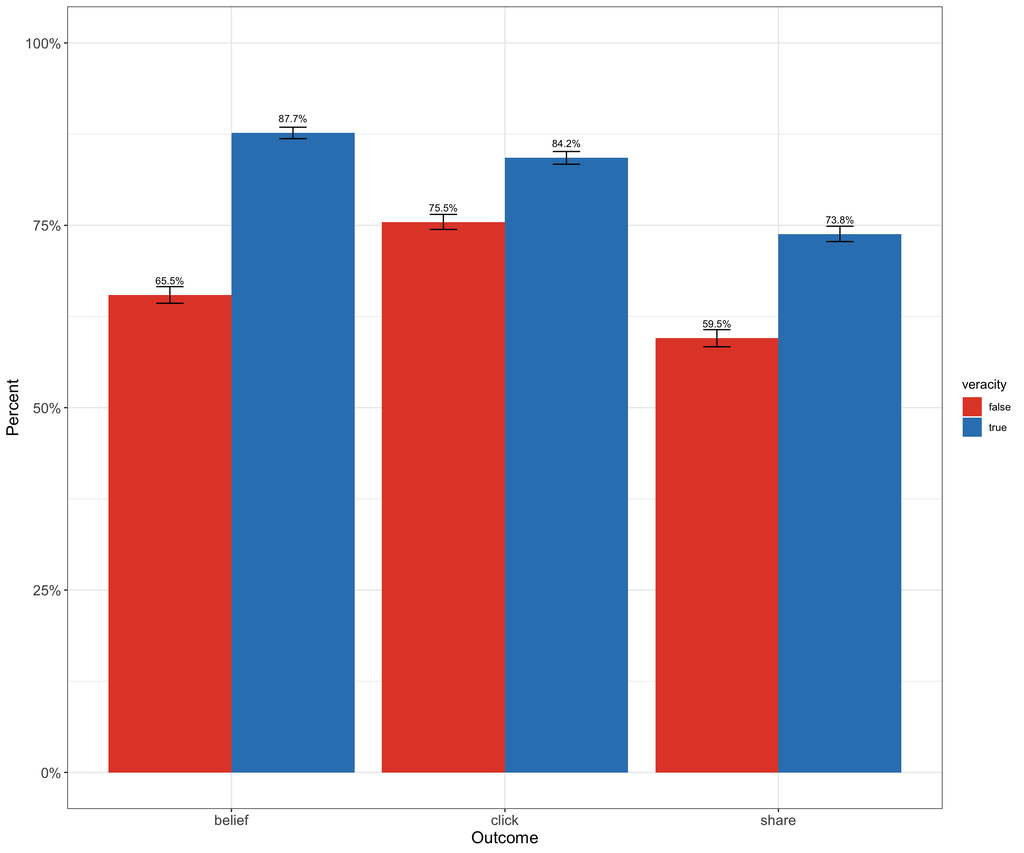

## Neutral or any emotion

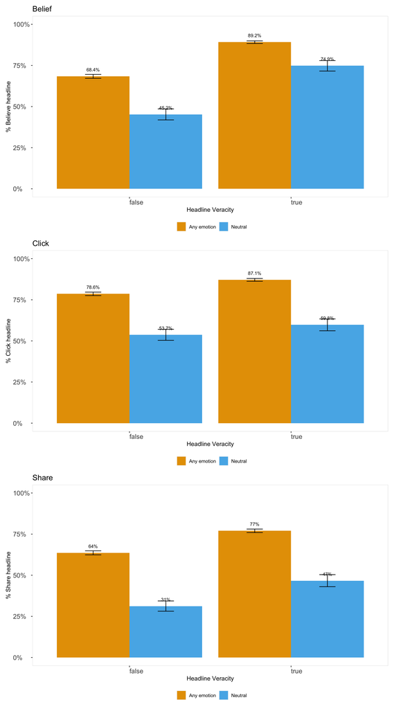

### Linear regression mixed effects model

|  | *Dependent variable:* |  |  |
| --- | --- | --- | --- |
|  | belief | click | share |
|  | (1) | (2) | (3) |
| neutralC | -0.172*** | -0.206*** | -0.224*** |
|  | (0.029) | (0.019) | (0.019) |
| trueC | 0.263*** | 0.071 | 0.148* |
|  | (0.090) | (0.066) | (0.079) |
| neutralC:trueC | 0.112* | -0.032 | 0.026 |
|  | (0.057) | (0.037) | (0.035) |
| Constant | 0.699*** | 0.719*** | 0.580*** |
|  | (0.045) | (0.033) | (0.040) |
| Observations | 13,410 | 13,409 | 13,409 |
| Log Likelihood | -5,996.359 | -5,329.677 | -6,794.762 |
| Akaike Inf. Crit. | 12,010.720 | 10,677.350 | 13,607.520 |
| Bayesian Inf. Crit. | 12,078.250 | 10,744.890 | 13,675.060 |
| *Note:* | p<0.1; p<0.05; p<0.01 |  |  |

### Logistic mixed effects model

|  | belief |  | click |  | share |  |
| --- | --- | --- | --- | --- | --- | --- |
| Predictors | Odds Ratios | p | Odds Ratios | p | Odds Ratios | p |
| (Intercept) | 4.21 | **<0.001** | 4.92 | **<0.001** | 1.96 | **0.010** |
| neutralC | 0.30 | **<0.001** | 0.22 | **<0.001** | 0.23 | **<0.001** |
| trueC | 7.54 | **<0.001** | 1.96 | 0.121 | 2.96 | **0.031** |
| neutralC * trueC | 0.85 | 0.541 | 0.51 | **0.005** | 0.92 | 0.695 |
| Random Effects |  |  |  |  |  |  |
| σ<sup>2</sup> | 3.29 |  | 3.29 |  | 3.29 |  |
| τ<sub>00</sub> | 1.44 <sub>respID</sub> |  | 2.37 <sub>respID</sub> |  | 3.48 <sub>respID</sub> |  |
|  | 0.77 <sub>headline</sub> |  | 0.46 <sub>headline</sub> |  | 0.63 <sub>headline</sub> |  |
| τ<sub>11</sub> | 0.11 <sub>headline.neutralC</sub> |  | 0.10 <sub>headline.neutralC</sub> |  | 0.05 <sub>headline.neutralC</sub> |  |
| ρ<sub>01</sub> | 0.01 <sub>headline</sub> |  | -0.68 <sub>headline</sub> |  | -0.80 <sub>headline</sub> |  |
| ICC | 0.40 |  | 0.47 |  | 0.56 |  |
| N | 1341 <sub>respID</sub> |  | 1341 <sub>respID</sub> |  | 1341 <sub>respID</sub> |  |
|  | 10 <sub>headline</sub> |  | 10 <sub>headline</sub> |  | 10 <sub>headline</sub> |  |
| Observations | 13410 |  | 13409 |  | 13409 |  |
| Marginal R<sup>2</sup> / Conditional R<sup>2</sup> | 0.186 / 0.515 |  | 0.070 / 0.510 |  | 0.068 / 0.592 |  |

## Anger

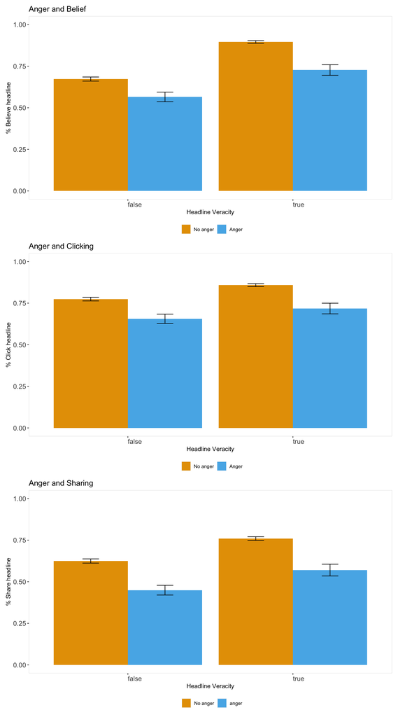

### Linear regression mixed effects model

|  | *Dependent variable:* |  |  |
| --- | --- | --- | --- |
|  | belief | click | share |
|  | (1) | (2) | (3) |
| angerC | -0.121*** | -0.097*** | -0.135*** |
|  | (0.046) | (0.036) | (0.039) |
| trueC | 0.270*** | 0.129** | 0.181** |
|  | (0.080) | (0.059) | (0.072) |
| angerC:trueC | 0.110 | 0.089 | 0.088 |
|  | (0.091) | (0.072) | (0.079) |
| Constant | 0.714*** | 0.760*** | 0.613*** |
|  | (0.040) | (0.030) | (0.037) |
| Observations | 13,410 | 13,409 | 13,409 |
| Log Likelihood | -6,083.703 | -5,456.297 | -6,890.745 |
| Akaike Inf. Crit. | 12,185.410 | 10,930.590 | 13,799.490 |
| Bayesian Inf. Crit. | 12,252.940 | 10,998.130 | 13,867.020 |
| *Note:* | p<0.1; p<0.05; p<0.01 |  |  |

### Logistic regression mixed effects model

|  | belief |  | click |  | share |  |
| --- | --- | --- | --- | --- | --- | --- |
| Predictors | Odds Ratios | p | Odds Ratios | p | Odds Ratios | p |
| (Intercept) | 4.59 | **<0.001** | 6.49 | **<0.001** | 2.42 | **<0.001** |
| angerC | 0.41 | **<0.001** | 0.49 | **0.001** | 0.40 | **<0.001** |
| trueC | 8.21 | **<0.001** | 2.87 | **0.015** | 3.55 | **0.007** |
| angerC * trueC | 1.00 | 0.995 | 1.38 | 0.456 | 1.36 | 0.512 |
| Random Effects |  |  |  |  |  |  |
| σ<sup>2</sup> | 3.29 |  | 3.29 |  | 3.29 |  |
| τ<sub>00</sub> | 1.48 <sub>respID</sub> |  | 2.52 <sub>respID</sub> |  | 3.70 <sub>respID</sub> |  |
|  | 0.67 <sub>headline</sub> |  | 0.45 <sub>headline</sub> |  | 0.53 <sub>headline</sub> |  |
| τ<sub>11</sub> | 0.47 <sub>headline.angerC</sub> |  | 0.36 <sub>headline.angerC</sub> |  | 0.45 <sub>headline.angerC</sub> |  |
| ρ<sub>01</sub> | -0.12 <sub>headline</sub> |  | -0.12 <sub>headline</sub> |  | -0.22 <sub>headline</sub> |  |
| ICC | 0.41 |  | 0.48 |  | 0.57 |  |
| N | 1341 <sub>respID</sub> |  | 1341 <sub>respID</sub> |  | 1341 <sub>respID</sub> |  |
|  | 10 <sub>headline</sub> |  | 10 <sub>headline</sub> |  | 10 <sub>headline</sub> |  |
| Observations | 13410 |  | 13409 |  | 13409 |  |
| Marginal R<sup>2</sup> / Conditional R<sup>2</sup> | 0.183 / 0.521 |  | 0.046 / 0.508 |  | 0.058 / 0.598 |  |

## Fear

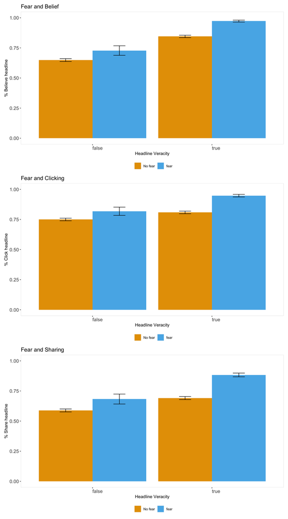

### Linear regression mixed effects model

|  | *Dependent variable:* |  |  |
| --- | --- | --- | --- |
|  | belief | click | share |
|  | (1) | (2) | (3) |
| fearC | 0.073** | 0.078*** | 0.099*** |
|  | (0.031) | (0.022) | (0.034) |
| trueC | 0.226*** | 0.090* | 0.163*** |
|  | (0.058) | (0.048) | (0.061) |
| fearC:trueC | 0.016 | 0.024 | 0.077 |
|  | (0.061) | (0.045) | (0.067) |
| Constant | 0.793*** | 0.826*** | 0.700*** |
|  | (0.029) | (0.025) | (0.031) |
| Observations | 13,410 | 13,409 | 13,409 |
| Log Likelihood | -6,121.023 | -5,483.299 | -6,906.449 |
| Akaike Inf. Crit. | 12,260.050 | 10,984.600 | 13,830.900 |
| Bayesian Inf. Crit. | 12,327.580 | 11,052.130 | 13,898.430 |
| *Note:* | p<0.1; p<0.05; p<0.01 |  |  |

### Logistic regression mixed effects model

|  | belief |  | click |  | share |  |
| --- | --- | --- | --- | --- | --- | --- |
| Predictors | Odds Ratios | p | Odds Ratios | p | Odds Ratios | p |
| (Intercept) | 8.83 | **<0.001** | 11.23 | **<0.001** | 4.44 | **<0.001** |
| fearC | 2.26 | **<0.001** | 2.24 | **<0.001** | 2.13 | **<0.001** |
| trueC | 10.08 | **<0.001** | 2.85 | **0.011** | 3.81 | **0.002** |
| fearC * trueC | 2.21 | **0.016** | 1.86 | 0.063 | 2.17 | **0.035** |
| Random Effects |  |  |  |  |  |  |
| σ<sup>2</sup> | 3.29 |  | 3.29 |  | 3.29 |  |
| τ<sub>00</sub> | 1.51 <sub>respID</sub> |  | 2.53 <sub>respID</sub> |  | 3.69 <sub>respID</sub> |  |
|  | 0.55 <sub>headline</sub> |  | 0.39 <sub>headline</sub> |  | 0.43 <sub>headline</sub> |  |
| τ<sub>11</sub> | 0.15 <sub>headline.fearC</sub> |  | 0.16 <sub>headline.fearC</sub> |  | 0.25 <sub>headline.fearC</sub> |  |
| ρ<sub>01</sub> | -0.38 <sub>headline</sub> |  | -0.25 <sub>headline</sub> |  | -0.59 <sub>headline</sub> |  |
| ICC | 0.40 |  | 0.48 |  | 0.57 |  |
| N | 1341 <sub>respID</sub> |  | 1341 <sub>respID</sub> |  | 1341 <sub>respID</sub> |  |
|  | 10 <sub>headline</sub> |  | 10 <sub>headline</sub> |  | 10 <sub>headline</sub> |  |
| Observations | 13410 |  | 13409 |  | 13409 |  |
| Marginal R<sup>2</sup> / Conditional R<sup>2</sup> | 0.196 / 0.516 |  | 0.054 / 0.505 |  | 0.060 / 0.594 |  |

## Happiness

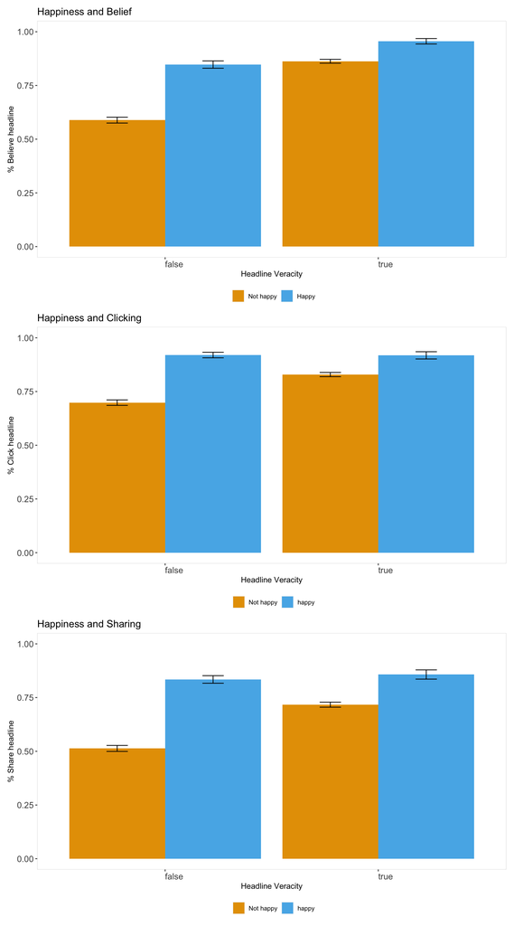

### Linear regression mixed effects model

|  | *Dependent variable:* |  |  |
| --- | --- | --- | --- |
|  | belief | click | share |
|  | belief | click | share |
|  | (1) | (2) | (3) |
| happyC | 0.155*** | 0.108*** | 0.158*** |
|  | (0.031) | (0.025) | (0.026) |
| trueC | 0.191*** | 0.077 | 0.109* |
|  | (0.057) | (0.049) | (0.062) |
| happyC:trueC | -0.196*** | -0.088* | -0.189*** |
|  | (0.062) | (0.049) | (0.052) |
| Constant | 0.802*** | 0.826*** | 0.705*** |
|  | (0.029) | (0.025) | (0.032) |
| Observations | 13,410 | 13,409 | 13,409 |
| Log Likelihood | -5,853.160 | -5,393.049 | -6,715.281 |
| Akaike Inf. Crit. | 11,724.320 | 10,804.100 | 13,448.560 |
| Bayesian Inf. Crit. | 11,791.850 | 10,871.630 | 13,516.090 |
| *Note:* | p<0.1; p<0.05; p<0.01 |  |  |

### Logistic mixed effects model

|  | belief |  | click |  | share |  |
| --- | --- | --- | --- | --- | --- | --- |
| Predictors | Odds Ratios | p | Odds Ratios | p | Odds Ratios | p |
| (Intercept) | 9.15 | **<0.001** | 12.28 | **<0.001** | 5.11 | **<0.001** |
| happyC | 3.21 | **<0.001** | 3.19 | **<0.001** | 3.71 | **<0.001** |
| trueC | 7.07 | **<0.001** | 2.25 | 0.066 | 2.54 | 0.057 |
| happyC * trueC | 0.48 | **0.031** | 0.52 | 0.121 | 0.32 | **0.001** |
| Random Effects |  |  |  |  |  |  |
| σ<sup>2</sup> | 3.29 |  | 3.29 |  | 3.29 |  |
| τ<sub>00</sub> | 1.42 <sub>respID</sub> |  | 2.55 <sub>respID</sub> |  | 3.90 <sub>respID</sub> |  |
|  | 0.57 <sub>headline</sub> |  | 0.45 <sub>headline</sub> |  | 0.58 <sub>headline</sub> |  |
| τ<sub>11</sub> | 0.17 <sub>headline.happyC</sub> |  | 0.32 <sub>headline.happyC</sub> |  | 0.17 <sub>headline.happyC</sub> |  |
| ρ<sub>01</sub> | -0.70 <sub>headline</sub> |  | 0.04 <sub>headline</sub> |  | -0.10 <sub>headline</sub> |  |
| ICC | 0.40 |  | 0.48 |  | 0.58 |  |
| N | 1341 <sub>respID</sub> |  | 1341 <sub>respID</sub> |  | 1341 <sub>respID</sub> |  |
|  | 10 <sub>headline</sub> |  | 10 <sub>headline</sub> |  | 10 <sub>headline</sub> |  |
| Observations | 13410 |  | 13409 |  | 13409 |  |
| Marginal R<sup>2</sup> / Conditional R<sup>2</sup> | 0.195 / 0.514 |  | 0.066 / 0.517 |  | 0.082 / 0.614 |  |